# Univariate Linear Regression

Using a line to fit data with one variable

Prediction model: $f(x) = wx + b$

$w, b$ are weights and bias of the model. Training aims improve prediction by adjusting the weights

# Notations

$x$: input varaible (features)

$y$: output variable ($y$ is continuous)

$m$: total number of training examples

$(x, y)$: a single training example

$(x^{(i)}, y^{(i)})$: the $ith$ training example

$\hat y$: the predicted output for the input $x$

Training set: data used to train the model

# Problem Statement

As in the lecture, you will use the motivating example of housing price prediction.  
This lab will use a simple data set with only two data points - a house with 1000 square feet(sqft) sold for \$300,000 and a house with 2000 square feet sold for \$500,000. These two points will constitute our *data or training set*. In this lab, the units of size are 1000 sqft and the units of price are 1000s of dollars.

| Size (1000 sqft) | Price (1000s of dollars) |
| --- | --- |
| 1.0 | 300 |
| 2.0 | 500 |

# Code

```python
import numpy as np
import matplotlib.pyplot as plt
```

```python
x_train = np.array([1.0,2.0])
y_train = np.array([300,500])
m = x_train.shape[0] # Length of the array
print(m)
```

```
2
```

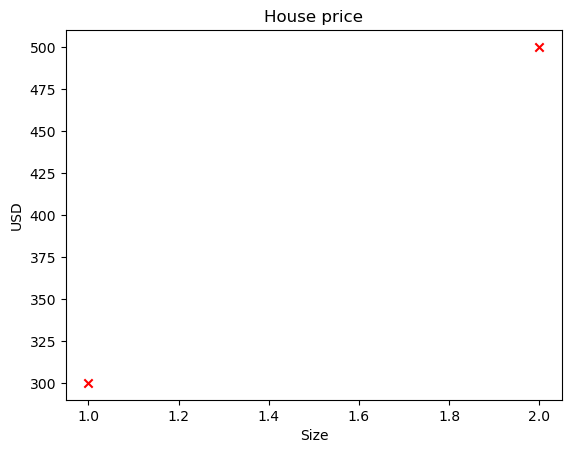

```python
# Data plotting
plt.scatter(x_train, y_train, marker = 'x',  c = 'r')
plt.title("House price")
plt.xlabel("Size")
plt.ylabel("USD")
plt.show()
```

```python
# Select variable w, b
w = 200
b = 100

# Create functiont to compute model output
def compute(x_train, w, b):
    m = x_train.shape[0]
    f = np.zeros(m) # Create an all 0 array for predicted values

    for i in range(m):
        f[i] =  w * x_train[i] + b # Compute all predicted values

    return f # Returns an array of output

compute(x_train, w, b)
```

```
array([300., 500.])
```

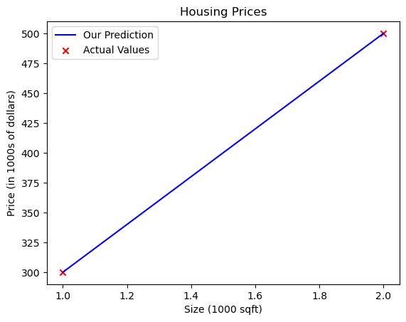

```python
# Plot prediction
f = compute(x_train, w, b,)

# Plot our model prediction
plt.plot(x_train, f, c='b',label='Our Prediction')

# Plot the data points
plt.scatter(x_train, y_train, marker='x', c='r',label='Actual Values')

# Set the title
plt.title("Housing Prices")
# Set the y-axis label
plt.ylabel('Price (in 1000s of dollars)')
# Set the x-axis label
plt.xlabel('Size (1000 sqft)')
plt.legend()
plt.show()
```

# Squared error cost function

Cost function measures the performance of a machine learning model by calculating the errors between the predicted values and expected values

Cost function: $$J(w, b) = \frac{1}{2m} \sum\limits_{i=0} ^{m-1} (f(x^{(i)}) - y^{(i)})^2 = \frac{1}{2m} \sum\limits_{i=0} ^{m-1}( \hat y^{(i)} - y^{(i)})^2$$

$m$: total number of training data

$f((x^{(i)}) - y^{(i)})$: error value (residual) for each data point

Goal: adjust $w, b$ to make $J$ as small as possible. A small $J$ value indicates a better fit to data

Each set of $w$ and $b$ value correspond to a different linear fit to the data and a $J$ value ($J$ value could be the same)

## Problem Statement

You would like a model which can predict housing prices given the size of the house.  
Let's use the same two data points as before the previous lab- a house with 1000 square feet sold for \$300,000 and a house with 2000 square feet sold for \$500,000.

| Size (1000 sqft) | Price (1000s of dollars) |
| --- | --- |
| 1 | 300 |
| 2 | 500 |

# Code

```python
x_train = np.array([1.0,2.0])
y_train = np.array([300,500])

def cost(x_train, y_train, w, b):
    m = x_train.shape[0]
    error_sum = 0

    for i in range(m):
        error_sum += (w * x_train[i] + b - y_train[i])**2

    cost = error_sum / (2 * m)

    return cost

cost(x_train, y_train, 200, 100)
```

```
0.0
```

# 3D Visualization of the cost function

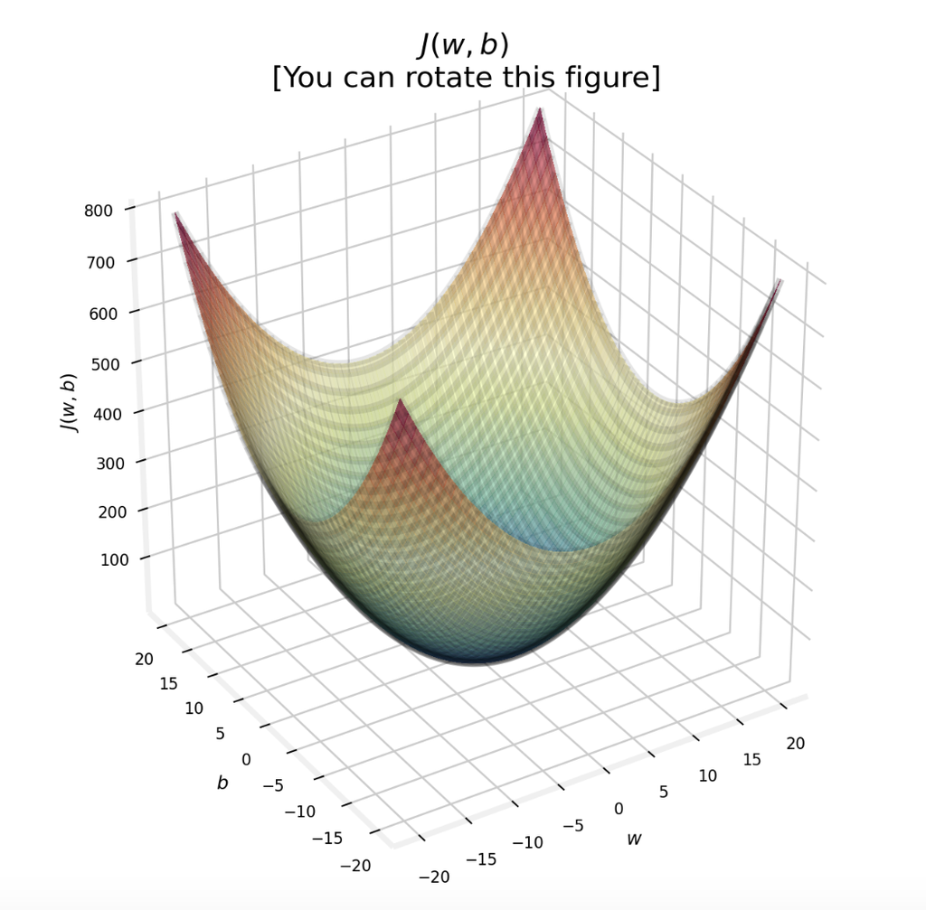

# Gradient Descent

Gradient descent algorithm determines the smallest possible $J$ value for a model

Steps:

1. Initialize random values for $w$, $b$ (0 in general)
2. Take a step in the opposite direction of the gradient of the function at the current point (direction of steepest descent), move to that point by updating $w$, $b$ to reduce cost
3. Repeat step2 until a local minimum is reached ($J$ can have more than 1 minimum)

Different starting points can lead to different local minima

## Update $w$ and $b$ values

$$\begin{align*} \text{Repeat}&\text{ until convergence:} \; \lbrace \newline \; w &= w - \alpha \frac{\partial J(w,b)}{\partial w} \; \newline b &= b - \alpha \frac{\partial J(w,b)}{\partial b} \newline \rbrace \end{align*}$$

Convergence: very small change in $w$, $b$ when each step is taken

Note: $w$ and $b$ must be updated simultaneously!

### Notations:

$\alpha$: Learning rate / step length of each step

$\frac{\partial J(w,b)}{\partial w}$, $\frac{\partial J(w,b)}{\partial b}$: the direction of the step taken

## Derivatives

$$ \begin{align} \frac{\partial J(w,b)}{\partial w} &= \frac{1}{m} \sum\limits_{i = 0}^{m-1} (f_{w,b}(x^{(i)}) - y^{(i)})x^{(i)} \\\ \frac{\partial J(w,b)}{\partial b} &= \frac{1}{m} \sum\limits_{i = 0}^{m-1} (f_{w,b}(x^{(i)}) - y^{(i)}) \\\ \end{align} $$

## Learning rate $\alpha$

Smaller $\alpha$, it takes more steps to reach the local minima but with higher accuracy

Larger $\alpha$, it takes less steps to reach the local minim but with less accuracy and may diverge

As the point get closer to the local minimum, $\alpha \frac{\partial J(w,b)}{\partial w}$ becomes smaller, which means the updated steps become smaller even with a fixed $\alpha$ value

# Problem Statement

Let's use the same two data points as before - a house with 1000 square feet sold for \$300,000 and a house with 2000 square feet sold for \$500,000.

| Size (1000 sqft) | Price (1000s of dollars) |
| --- | --- |
| 1 | 300 |
| 2 | 500 |

# Code

```python
x_train = np.array([1.0, 2.0])
y_train = np.array([300.0, 500.0])
```

```python
# Function that computes the gradients for w and b
def compute_gradient(x_train, y_train, w, b):
    m = x_train.shape[0]
    gw, gb = 0, 0

    for i in range(m):
        gw += (w * x_train[i] + b - y_train[i]) * x_train[i]
        gb += (w * x_train[i] + b - y_train[i])

    gw /= m
    gb /= m

    return gw, gb

compute_gradient(x_train, y_train, 0, 0)
```

```
(-650.0, -400.0)
```

```python
# Learning function
def gradient(x = x_train, y = y_train, alpha = 0.01, w = 0, b = 0, iterations = 10000):
    m = x.shape[0]
    for i in range(iterations):
        gw, gb = compute_gradient(x, y, w, b)
        w -= alpha * gw
        b -= alpha * gb
        # print(w, b, f"Cost: { (w * x[j] -y[j]) / (2 * m) for j in range(m) }")
    return w, b
```

```python
# Cost decreases with iterations
gradient(x_train, y_train, 0.01, 0, 0, 10000)
```

```
(199.99285075131766, 100.011567727362)
```

```python
# Final model
def price(area):
    w, b = gradient()

    return w * area + b
```

```python
price(2)
```

```
499.9972692299973
```

# Multiple linear regression

## Prediction model:

$$f(\vec {x}) = w_{1}x_{1} + w_{2}x_{2} + ... + w_{n}x_{n} + b \\ = \vec {w} \cdot \vec {x} + b$$

### Notations

$x_{j}$: $j$th feature

$n$: total numbers of featuers

$\vec {x}^{(i)}$: a vector represent all the features in $i$th training example

$x_{j}^{(i)}$: $j$th feature in $i$th training example

$w_{(j)}$: weight of $j$th feature

$\vec {w}$: a row vector that contains all weights ($\vec {w} = [w_{1}\ w_{2}\ ...\ w_{n}]$)

$\vec {x}$: a row vector that contains all features ($\vec {x} = [x_{1}\ x_{2}\ ...\ x_{n}]$)

Note: use verorization to improve the run time

# Gradient descent for multiple linear regression

Cost function: $J(\vec {w}, b) $ $$J(\vec {w}, b) = \frac{1}{2m} \sum\limits_{i = 0}^{m-1} (f_{\vec{w}, b}(\vec {x}^{(i)}) - y^{(i)})^2 $$ where: $$ f_{\vec {w}, b}(\vec {x}^{(i)}) = \vec {w} \cdot \vec {x}^{(i)} + b $$

## Updating $w$ and $b$ of $j$th feature

$$\begin{align*} \text{repeat}&\text{ until convergence:} \; \lbrace \newline\; & w_j = w_j - \alpha \frac{\partial J(\vec {w},b)}{\partial w_j} \ \; & \text{for j = 0..n-1}\newline &b\ \ = b - \alpha \frac{\partial J(\vec {w},b)}{\partial b} \newline \rbrace \end{align*}$$

## Derivatives

$$ \begin{align} \frac{\partial J(\vec{w},b)}{\partial w_j} &= \frac{1}{m} \sum\limits_{i = 0}^{m-1} (f_{\vec{w},b}(\vec{x}^{(i)}) - y^{(i)})x_{j}^{(i)} \ \\ \frac{\partial J(\vec{w},b)}{\partial b} &= \frac{1}{m} \sum\limits_{i = 0}^{m-1} (f_{\vec{w},b}(\vec{x}^{(i)}) - y^{(i)}) \ \end{align} $$

# Problem Statement

You will use the motivating example of housing price prediction. The training dataset contains three examples with four features (size, bedrooms, floors and, age) shown in the table below. Note that, unlike the earlier labs, size is in sqft rather than 1000 sqft. This causes an issue, which you will solve in the next lab!

| Size (sqft) | Number of Bedrooms | Number of floors | Age of Home | Price (1000s dollars) |
| --- | --- | --- | --- | --- |
| 2104 | 5 | 1 | 45 | 460 |
| 1416 | 3 | 2 | 40 | 232 |
| 852 | 2 | 1 | 35 | 178 |

You will build a linear regression model using these values so you can then predict the price for other houses. For example, a house with 1200 sqft, 3 bedrooms, 1 floor, 40 years old.

Please run the following code cell to create your `X_train` and `y_train` variables.

# Code

```python
x_train = np.array([[2104, 5, 1, 45], [1416, 3, 2, 40], [852, 2, 1, 35]])
y_train = np.array([460, 232, 178])
print(x_train)
print(y_train)
```

```
[[2104    5    1   45]
 [1416    3    2   40]
 [ 852    2    1   35]]
[460 232 178]
```

```python
w = np.array([0, 0, 0, 0])
b = 0
```

```python
# Prediction function
def multi_predict(x, w, b):
    pred = np.dot(x, w) + b
    return pred

multi_predict(x_train, w, b)
```

```
array([0, 0, 0])
```

```python
# Cost function
def multi_cost(X, Y, w, b):
    m = X.shape[0] # find nubmers of training examples
    cost = 0

    for i in range(m):
        cost += (np.dot(w, X[i]) + b - Y[i])**2

    cost /= 2 * m

    return cost

multi_cost(x_train, y_train, w, b)
```

```
49518.0
```

```python
# Compute gradient
def multi_compute_gradient(X, Y, w, b):
    m = X.shape[0]
    n = X.shape[1] # find the number of features

    gw = np.zeros(n) # gw is an array with n elements
    gb = 0

    for i in range(m):
        gb += np.dot(w, X[i]) + b - Y[i]

        # this loop compute one gradient in each iteration
        for j in range(n):
            gw[j] += (np.dot(w, X[i]) + b - Y[i]) * X[i, j]

    gw /= m
    gb /= m
    return gw, gb

multi_compute_gradient(x_train, y_train, w, b)
```

```
(array([-4.83e+05, -1.12e+03, -3.67e+02, -1.21e+04]), -290.0)
```

```python
# Learning function
np.set_printoptions(precision=2)

def multi_gradient(w, b, X = x_train, Y = y_train, alpha = 5.0e-7, iterations = 1000):

    for i in range(iterations):
        gw, gb = multi_compute_gradient(X, Y, w, b)
        #print(w, gw)
        w = w - alpha * gw
        b = b - alpha * gb
        # print(w, b, f"Cost: { (w * x[j] -y[j]) / (2 * m) for j in range(m) }")
    return w, b
```

```python
w, b = multi_gradient(w, b)
print(w, b)
multi_cost(x_train, y_train, w, b)
```

```
[ 0.2   0.   -0.01 -0.07] -0.0022354075309325345
```

```
686.7034116665213
```

# Techniques

## Feature scaling

When a feature has can be a wide range of values, its weight is likely to be small

When a feature has can be a small range of values, its weight is likely to be large

When features have siginificantly different range of values, gradient descent can run very slowly. Therefore, scaling the features' data can improve the run time

Feature scaling aims for $-1 \leq x_j \leq 1$ for the $j$th feature

## Feature scaling methods

- 1. Divide each feature with its largest possible value
- 2. Mean normalization: Find the mean($\mu_j$) for each feature ($x_j$), and normalize the feature with the following formula $x_j = \dfrac{x_j - \mu_j}{max - min} $
- 3. Z-score normalization

### Z-score normalization

Z-score normalization centers the data around the origin

Steps

1. Calculate the mean($\mu_j$) and standard deviation($\sigma_j$) for the $j$th feature, where $$ \begin{align} \mu_j &= \frac{1}{m} \sum_{i=0}^{m-1} x^{(i)}_j \\ \sigma^2_j &= \frac{1}{m} \sum_{i=0}^{m-1} (x^{(i)}_j - \mu_j)^2 \end{align} $$
2. Normalize $j$th feature with the following formula: $$x^{(i)}_j = \dfrac{x^{(i)}_j - \mu_j}{\sigma_j} $$ After z-score normalization, all features will have a mean of 0 and a standard deviation of 1.

## Convergence of gradient descent

If gradient descent works properly, the cost($J$) should decrease after each iteration of gradient descent

If the cost doesn't change significantly, the cost function is likely converged

## Choice of learning rate ($\alpha$)

An increase in the cost indicates the learning rate is too large and should be decreased

Try different range of learning rate

## Feature engineering

Design new features by transforming or combining given features (eg. given width and length, we can engineer area as a new feature)

## Polynomial regression

Polynomial regression fits non-linear functions to the data

Feature scaling becomes more important in polynomial regression

```python
# Z-score normalization
def z_score(X):
    mu = np.mean(X, axis = 0) # Compute the mean for each feature
    sigma = np.std(X, axis = 0) # Compute the standard deviation for each feature

    X_norm = (X - mu) / sigma # vectorized operation

    return (X_norm, mu, sigma)

print(x_train)
print(z_score(x_train))
```

```
[[2104    5    1   45]
 [1416    3    2   40]
 [ 852    2    1   35]]
(array([[ 1.26,  1.34, -0.71,  1.22],
       [-0.08, -0.27,  1.41,  0.  ],
       [-1.18, -1.07, -0.71, -1.22]]), array([1.46e+03, 3.33e+00, 1.33e+00, 4.00e+01]), array([5.12e+02, 1.25e+00, 4.71e-01, 4.08e+00]))
```

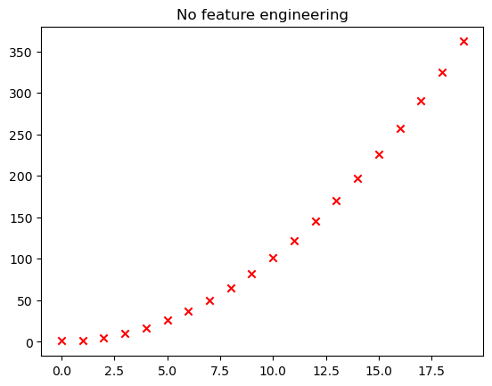

```python
# Feature engineering & polynomial regression

# e.g. If we want to fit f(x) = 1 + x^2

# create target data
x = np.arange(0, 20, 1)
y = 1 + x**2
X = x.reshape(-1, 1)

plt.scatter(x, y, marker='x', c='r', label="Actual Value"); plt.title("No feature engineering")
```

[output not shown]

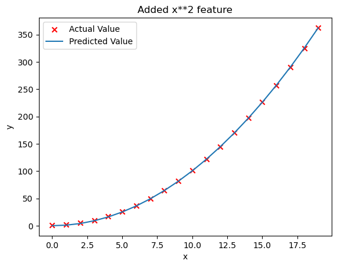

```python
# Create training data
x = np.arange(0.0, 20.0, 1)
y = 1 + x**2
print(x, y)

# Feature engineering
X = x**2

X = X.reshape(-1, 1)  #X should be a 2-D Matrix
model_w,model_b = multi_gradient(0, 0, X, y, iterations=10000, alpha = 1e-5)

plt.scatter(x, y, marker='x', c='r', label="Actual Value"); plt.title("Added x**2 feature")
plt.plot(x, np.dot(X,model_w) + model_b, label="Predicted Value"); plt.xlabel("x"); plt.ylabel("y"); plt.legend(); plt.show()
```

# Tools

Scikit-Learn: https://scikit-learn.org/stable/